# Homework 05

Netid: ghosh17

Subhankar Ghosh

## Question 1

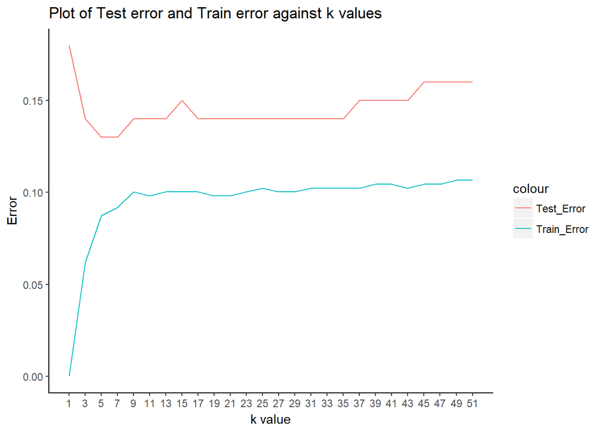

```r
#library(class)

train_data = read.csv("wisc-trn.csv")
test_data = read.csv("wisc-tst.csv")

train_data$class = as.factor(train_data$class)
test_data$class = as.factor(test_data$class)

set.seed(314)

# Separating response variables from predictor variables
train_class = train_data$class
test_class = test_data$class
train_x = train_data[, -1]
test_x = test_data[, -1]

# Function to calculate classification error
class_err = function(actual, predicted) {
  mean(actual != predicted)
}

kval = seq(1, 52, 2)
err_test = rep(x = 0, times = length(kval))
err_train = rep(x = 0, times = length(kval))

for (i in seq_along(kval)) {
  pred = class::knn(train = train_x,
             test  = train_x,
             cl    = train_class,
             k     = kval[i])
  err_train[i] = class_err(train_class, pred)

  pred = class::knn(train = train_x,
             test  = test_x,
             cl    = train_class,
             k     = kval[i])
  err_test[i] = class_err(test_class, pred)
}


RMSEdf2 = data.frame(KValue = kval, Train_Error = err_train,
                     Test_Error = err_test)

library(ggplot2)

p = ggplot(RMSEdf2, aes(KValue)) +
  geom_line(aes(y = Train_Error, colour = "Train_Error")) +
  geom_line(aes(y = Test_Error, colour = "Test_Error"))
# Give proper labels
p = p + xlab("k value") + ylab("Error") + ggtitle("Plot of Test error and Train error against k values")
# Select background theme and x axis & y axis line themes
p = p + theme(panel.background = element_rect(fill = "white"), axis.line.x = element_line(color = "black", linetype = "solid", size = 0.5), axis.line.y = element_line(color = "black", linetype = "solid", size = 0.5))
# modify x axis to show all degrees
p = p + scale_x_continuous(breaks = kval)
p
```

## Question 2

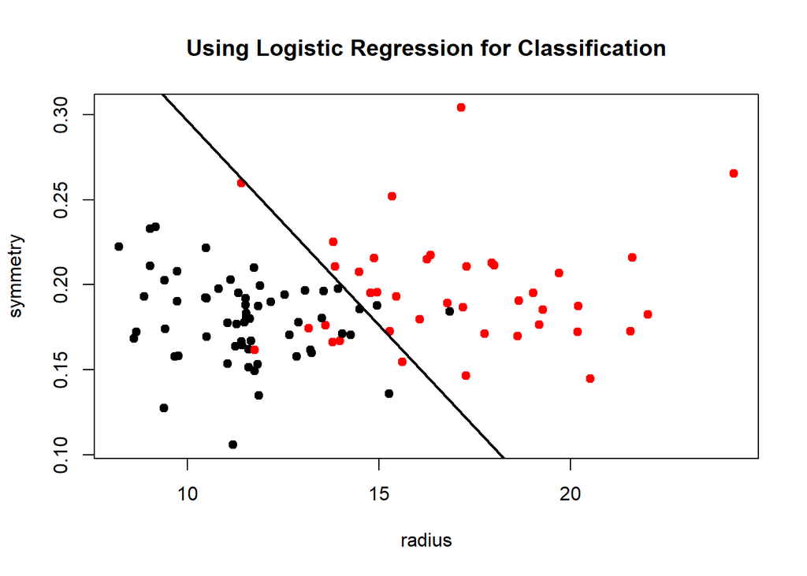

```r
model_glm = glm(class ~ radius + symmetry, data = train_data, family = "binomial")

plot(symmetry ~ radius, data = test_data,
     col = class, pch = 19,
     main = "Using Logistic Regression for Classification")
abline(a = -coef(model_glm)[1]/coef(model_glm)[3], b = -coef(model_glm)[2]/coef(model_glm)[3], lwd = 2)
```

*The black line is the decision boundary.*

## Question 3

```r
get_logistic_pred = function(model, data, res = "y", pos = 1, neg = 0, cut = 0.5) {
  probs = predict(model, newdata = data, type = "response")
  preds = ifelse(probs > cut, pos, neg)
  preds
}

test_pred_10 = get_logistic_pred(model_glm, data = test_data, res = "class",
                                 pos = "M", neg = "B", cut = 0.1)
test_pred_50 = get_logistic_pred(model_glm, data = test_data, res = "class",
                                 pos = "M", neg = "B", cut = 0.5)
test_pred_90 = get_logistic_pred(model_glm, data = test_data, res = "class",
                                 pos = "M", neg = "B", cut = 0.9)

library(caret)
library(e1071)
test_tab_10 = table(predicted = test_pred_10, actual = test_data$class)
test_tab_50 = table(predicted = test_pred_50, actual = test_data$class)
test_tab_90 = table(predicted = test_pred_90, actual = test_data$class)

test_con_mat_10 = caret::confusionMatrix(test_tab_10, positive = "M")
test_con_mat_50 = caret::confusionMatrix(test_tab_50, positive = "M")
test_con_mat_90 = caret::confusionMatrix(test_tab_90, positive = "M")

metrics = rbind(

  c(test_con_mat_10$overall["Accuracy"],
    test_con_mat_10$byClass["Sensitivity"],
    test_con_mat_10$byClass["Specificity"]),

  c(test_con_mat_50$overall["Accuracy"],
    test_con_mat_50$byClass["Sensitivity"],
    test_con_mat_50$byClass["Specificity"]),

  c(test_con_mat_90$overall["Accuracy"],
    test_con_mat_90$byClass["Sensitivity"],
    test_con_mat_90$byClass["Specificity"])

)

rownames(metrics) = c("c = 0.10", "c = 0.50", "c = 0.90")
knitr::kable(metrics)
```

|  | Accuracy | Sensitivity | Specificity |
| --- | --- | --- | --- |
| c = 0.10 | 0.86 | 0.950 | 0.8000000 |
| c = 0.50 | 0.91 | 0.825 | 0.9666667 |
| c = 0.90 | 0.82 | 0.575 | 0.9833333 |

## Question 4

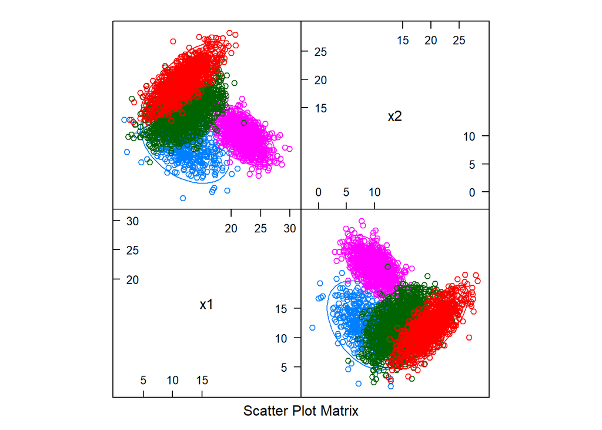

```r
trn_data = read.csv("D:\\Coursework\\Fall17\\430\\hw05-trn.csv")
tst_data = read.csv("D:\\Coursework\\Fall17\\430\\hw05-tst.csv")

trn_data$y = as.factor(trn_data$y)
tst_data$y = as.factor(tst_data$y)

library(ellipse)

caret::featurePlot(x = trn_data[, -1],
            y = trn_data$y,
            plot = "ellipse")
```

```r
library(nnet)
# logistic Model
log_mdl = multinom(y ~ ., data = trn_data, family = "binomial")
library(MASS)
# LDA (with Priors estimated from data)
lda_mdl = lda(y ~ ., data = trn_data)

# LDA with flat Priors
lda_flat_mdl = lda(y ~ ., data = trn_data, prior = c(1, 1, 1, 1) / 4)


# QDA (with Priors estimated from data)
qda_mdl = qda(y ~ ., data = trn_data)

# QDA with flat Priors
qda_flat_mdl = qda(y ~ ., data = trn_data, prior = c(1, 1, 1, 1) / 4)

# Naive bayes
nb_mdl = naiveBayes(y ~ ., data = trn_data)

trn_err_log = class_err(predict(log_mdl, trn_data), trn_data$y)
trn_err_lda = class_err(predict(lda_mdl, trn_data)$class, trn_data$y)
trn_err_lda_flat = class_err(predict(lda_flat_mdl, trn_data)$class, trn_data$y)
trn_err_qda = class_err(predict(qda_mdl, trn_data)$class, trn_data$y)
trn_err_qda_flat = class_err(predict(qda_flat_mdl, trn_data)$class, trn_data$y)
trn_err_nb = class_err(predict(nb_mdl, trn_data, type = "class"), trn_data$y)


tst_err_log = class_err(predict(log_mdl, tst_data), tst_data$y)
tst_err_lda = class_err(predict(lda_mdl, tst_data)$class, tst_data$y)
tst_err_lda_flat = class_err(predict(lda_flat_mdl, tst_data)$class, tst_data$y)
tst_err_qda = class_err(predict(qda_mdl, tst_data)$class, tst_data$y)
tst_err_qda_flat = class_err(predict(qda_flat_mdl, tst_data)$class, tst_data$y)
tst_err_nb = class_err(predict(nb_mdl, tst_data, type = "class"), tst_data$y)

out_df = data.frame(Name = c('Logistic', 'lda', 'lda flat', 'qda', 'qda flat', 'naive bayes'),
                    Train_Error = c(trn_err_log, trn_err_lda, trn_err_lda_flat, trn_err_qda, trn_err_qda_flat, trn_err_nb),
                    Test_Error = c(tst_err_log, tst_err_lda, tst_err_lda_flat, tst_err_qda, tst_err_qda_flat, tst_err_nb))

knitr::kable(out_df)
```

| Name | Train_Error | Test_Error |
| --- | --- | --- |
| Logistic | 0.1482222 | 0.17425 |
| lda | 0.1620000 | 0.19825 |
| lda flat | 0.1906667 | 0.16875 |
| qda | 0.1477778 | 0.16925 |
| qda flat | 0.1791111 | 0.14000 |
| naive bayes | 0.1733333 | 0.20000 |

## Question 5

**(a)** Which k performs best in Exercise 1?

**Ans:** k = 5 and 7 gives the best miscalssification rate.

**(b)** In Exercise 4, which model performs best?

**Ans:** QDA with Flat prior performs the best in Exercise 4

**(c)** In Exercise 4, why does Naive Bayes perform poorly?

**Ans:** Naive bayes is performing the worst because it assumes independent predictors and it performs well with large n which is not the case here.

**(d)** In Exercise 4, which performs better, LDA or QDA? Why?

**Ans:** QDA performs better than LDA since it has lower misclassification rate. This happens because the predictors have different variances (which can be seen from the feature plot) therefore a quadratic decision boundary fits the data better.

**(e)** In Exercise 4, which prior performs better? Estimating from data, or using a flat prior? Why?

**Ans:** Flat prior performs better in this particular case. By looking at the ellipse plot we can see that the classes are uniformly distributed and since in flat prior we assume the distribution of the classes to be uniform therefore it performs better.

**(f)** In Exercise 4, of the four classes, which is the easiest to classify?

**Ans:** Class B is the easiest to classify since we can see from the ellipse plot that class B is not overlapping as is the case with other classes.